# R Midterm: Lubridate

Ryan Klein, Vijayalakshmi Indupuru, and Damir Hrnjez

[figure not shown]

## Package Overview: Lubridate

- The main purpose of Lubridate is to make working with dates and times simpler.
- Methods for dealing with date-time objects must be robust to changes in time such as leap years, time zones, daylight-savings time, seasons, and many other unique aspects of time.
- With this package one can manipulate, parse, and extract date/time data as well as perform algebraic operations
  - Grouping these tools by common purpose is helpful
- Uses a very memorable syntax that makes working with Lubridate very easy
- Examples of function groups
  - Parsing Dates
  - Manipulating Dates
  - Rounding Dates
  - Time Zones
  - Durations
  - Intervals
- Main authors of Lubridate are Garrett Grolemund and Hadley Wickham.
- Lubridate currently operates on version 1.7.9.

## Necessary Packages

```r
library(tidyverse)
library(knitr)
library(lubridate)
```

## Examples of Usage

### as_date

as_date(): this function converts an object into a date or date-time

```r
vect <- c("04/26/2008", "12/25/1990", "01/01/2000")
class(vect)
```

```
## [1] "character"
```

```r
# %Y-%m-%d is the default format, the following line fails
vect_dt <- as_date(vect)
vect_dt <- as_date(vect, format = "%m/%d/%Y")
vect_dt
```

```
## [1] "2008-04-26" "1990-12-25" "2000-01-01"
```

```r
class(vect_dt)
```

```
## [1] "Date"
```

### Get/Set Functions

```r
x <- as_date("2005-05-10 5:17:42")
day(x)
```

```
## [1] 10
```

```r
day(x) <- 17
day(x)
```

```
## [1] 17
```

```r
x
```

```
## [1] "2005-05-17"
```

```r
minute(x)
```

```
## [1] 0
```

```r
y <- ("2005-05-10 5:17:42")
hour(y)
```

```
## [1] 5
```

```r
second(y)
```

```
## [1] 42
```

```r
minute(y)
```

```
## [1] 17
```

```r
month(y)
```

```
## [1] 5
```

```r
year(y)
```

```
## [1] 2005
```

### Date “Math”

```r
y <- as_date("2018-10-26")
z <- y + days(2)
z
```

```
## [1] "2018-10-28"
```

```r
reg_time <- now(tzone = 'EST')
daylight_svngs <- reg_time + hours(1)
reg_time
```

```
## [1] "2020-10-10 11:44:23 EST"
```

```r
daylight_svngs
```

```
## [1] "2020-10-10 12:44:23 EST"
```

```r
#adding durations and intervals together
start_2020 <- ymd_hms("2020-01-01 12:00:00")
new_week <- ddays(7)
first_week_2020 <- start_2020 + new_week
first_week_2020
```

```
## [1] "2020-01-08 12:00:00 UTC"
```

```r
tm_corona <- ymd_hm("2020-03-12 11:45", tz = "US/Eastern")
tm_now <- now()
difftime(tm_now, tm_corona, units = "weeks")
```

```
## Time difference of 30.29161 weeks
```

```r
christmas <- ymd("2020-12-25")
new_year <- ymd("2021-01-01")
interval <- new_year - christmas

z <- interval/ddays(1)
z
```

```
## [1] 7
```

## Graph Using Time Data

### Code

```r
str(lakers$date)
lakers$date <- ymd(lakers$date)
str(lakers$date)
lakers$game_type <- as.factor(lakers$game_type)
home_away <<- ggplot(lakers, aes(x = date, y = 0)) +
  geom_point(aes(color = game_type)) +
  labs(title = "2008 Home and Away Games for the Lakers Over Time") +
  xlab("Date of Game") +
  ylab("") +
  scale_y_continuous(breaks = seq(0, 1, 1)) +
  scale_color_discrete("Home or Away Game")
  theme(axis.text.y = element_blank()
)
```

### Graph

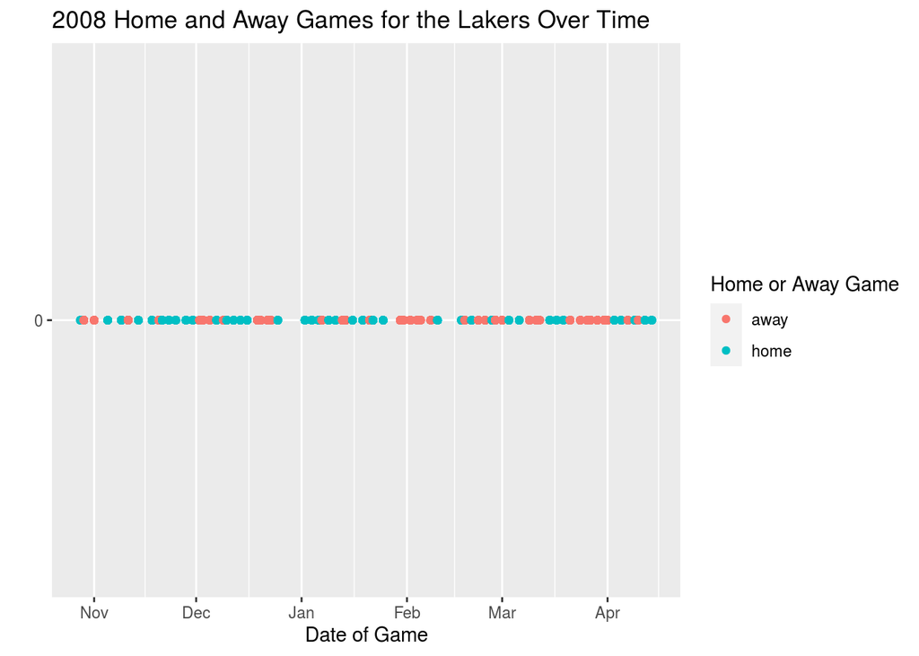

```r
home_away
```

## Our Opinion

### Pros:

- Lubridate is the perfect package for working with date-time data. Nearly all the benefits of lubridate involve making date-time data manipulation much easier. Here are the key benefits that lubridate offers as a package in R.
- Much better than other R functions for manipulating and performing operations on time data.
  - Easier to identify and parse date-time data
  - Easier to extract specific components of a date-time, like year, month, days, hours, minutes
  - Easier to perform accurate calculations with date-time
  - Easier to handle time zones and daylight savings time
- Time data is made it’s own date type, depending on the method used
- Uses an intuitive user interface
- Syntax is much more easy to use and more memorable
- Includes functions that apply to every combination of how dates can be represented
- Useful for comparing time data to each other

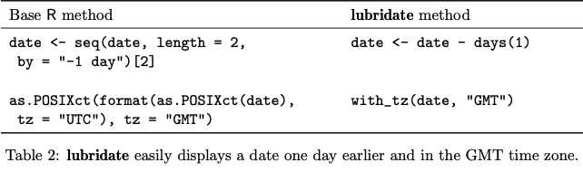

[Link to Download Graphic](https://www.jstatsoft.org/article/view/v040i03/v40i03.pdf)

### Cons:

- Beyond compatibility with other packages in R, lubridate does not have many cons in terms of functionality. Created as a solution to dealing with date-time data, lubridate serves to do just that.
- For its default setting Lubridate uses time instants expressed in UTC, which isn’t associated with a time zone and does not take into account daylight savings
- There isn’t complete compatibility between lubridate and dplyr, particularly in older versions of the softwares
  - Ex: dplyr can’t deal with the duration class, would need to convert to numeric

## Citations

1. https://lubridate.tidyverse.org
2. https://rawgit.com/rstudio/cheatsheets/master/lubridate.pdf
3. https://data.library.virginia.edu/working-with-dates-and-time-in-r-using-the-lubridate-package/
4. https://cran.r-project.org/web/packages/lubridate/vignettes/lubridate.html#
5. https://cran.r-project.org/web/packages/lubridate/lubridate.pdf
6. https://www.rdocumentation.org/packages/lubridate/versions/1.7.9
7. https://www.google.com/url?sa=i&url=https%3A%2F%2Flubridate.tidyverse.org%2F&psig=AOvVaw0tGvtqCQacuObJXBoGqht5&ust=1602202802988000&source=images&cd=vfe&ved=0CAIQjRxqFwoTCNDo8dnco-wCFQAAAAAdAAAAABAD